# Final Project

The first step is to create the dataset by pulling values and generating the rate of change of interest (i.e., log-returns)

```r
pacman::p_load(quantmod, tseries, qmao)
```

First question was to determine which of the 2 most common attributes to use (i.e., returns or log returns))

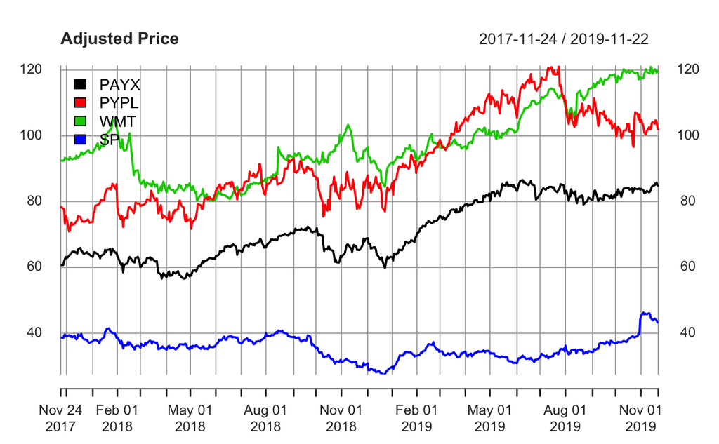

```r
pdf("Figure1-price.pdf",height=7,width=8)
plot(as.xts(df_adj), main="Adjusted Price", legend.loc = "topleft")
graphics.off()

plot(as.xts(df_adj), main="Adjusted Price", legend.loc = "topleft")
```

**Figure 1.** Time-Series plot for the Adjusted Price of PayCheck Inc, PayPal, Walmart and SP.

At first glance we can observe quite some difference between the price values for the individual stocks and the market price.

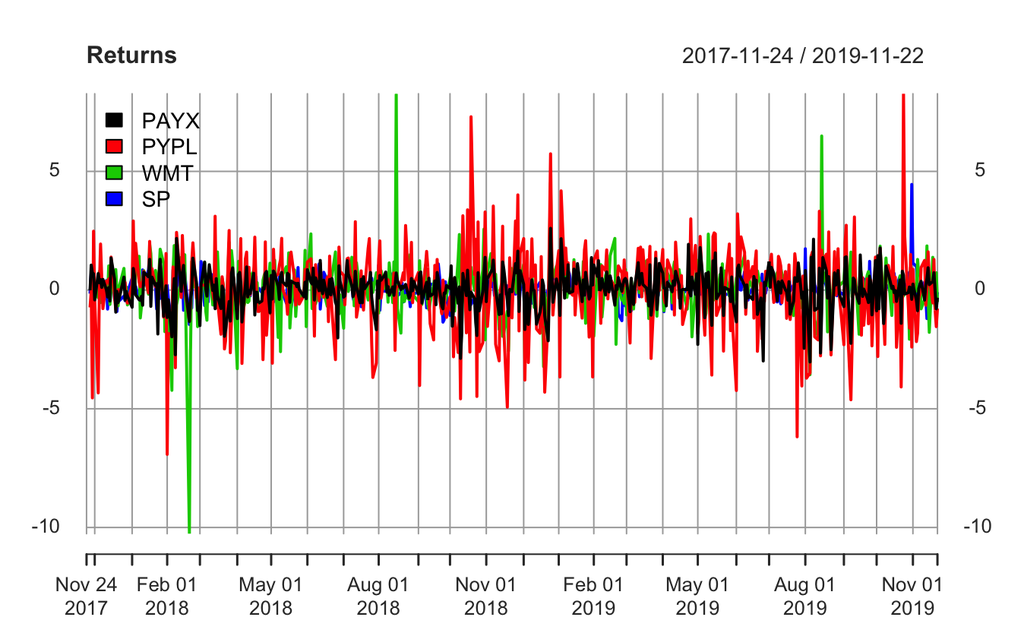

```r
pdf("Figure2-returns.pdf",height=7,width=8)
plot(as.xts(df_ret), main="Returns", legend.loc = "topleft")
graphics.off()

plot(as.xts(df_ret), main="Returns", legend.loc = "topleft")
```

**Figure 2.** Time-Series plot for the returns for PayCheck Inc, PayPal, Walmart and SP.

The time-series starts to show a mean-reversion condition which is an indicator used to identify distributional invariance over time, or stationarity. However, it seems that we can’t observe well the S&P 500 returns (i.e., blue lines).

**Key Concept:** An important consideration when modeling time series is the principle of parsimony. This principle refers to representing the systematic structure of the series with as few parameters as possible. Essentially, this means simpler representations of a time series process are more desirable than more complex ones if both are adequate. (Chapter 2. Autoregressive Integrated Moving Average Models) (http://www.scausa.com/tsfbook.php#:~:targetText=An%20important%20consideration%20when%20modeling,as%20few%20parameters%20as%20possible.&targetText=This%20chapter%20examines%20seasonal%20time,are%20useful%20for%20such%20data)

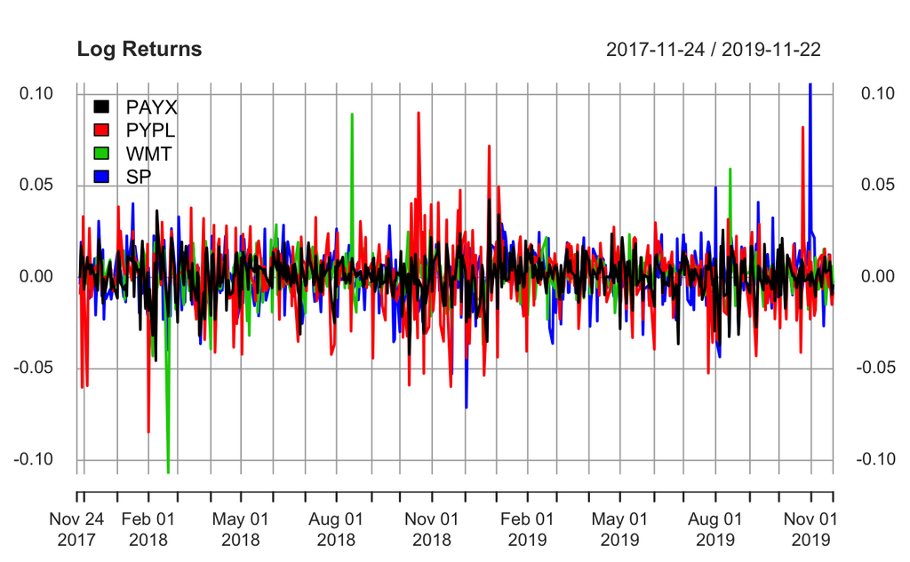

```r
pdf("Figure3-log-returns.pdf",height=7,width=8)
plot(as.xts(df_log_ret), main="Log Returns", legend.loc = "topleft")
graphics.off()

plot(as.xts(df_log_ret), main="Log Returns", legend.loc = "topleft")
```

**Figure 3.** Time-Series plot for the log returns for PayCheck Inc, Paypal, Walmart and SP.

The time-series continues to show the mean-reversion condition and on top the color code for each security seems to be more evently distributed, including S&P 500.

Since the log-returns seems to show better the parsimony principle; we will continue the analysis using the log-return transformation.

# Are the time series stationary?

```r
pdf("Figure4-ACF-lag-default.pdf",height=7,width=8)
par(mfrow=c(2,2))
acf(df_log_ret[,"PAYX"], main="PayCheck Inc.", na.action = na.pass)
acf(df_log_ret[,"PYPL"], main="PayPal", na.action = na.pass)
```

```r
acf(df_log_ret[,"WMT"], main="Walmart", na.action = na.pass)
acf(df_log_ret[,"SP"], main="S&P 500", na.action = na.pass)
```

```r
graphics.off()

par(mfrow=c(2,2))
acf(df_log_ret[,"PAYX"], main="PayCheck Inc.", na.action = na.pass)
```

```r
acf(df_log_ret[,"PYPL"], main="PayPal", na.action = na.pass)
acf(df_log_ret[,"WMT"], main="Walmart", na.action = na.pass)
```

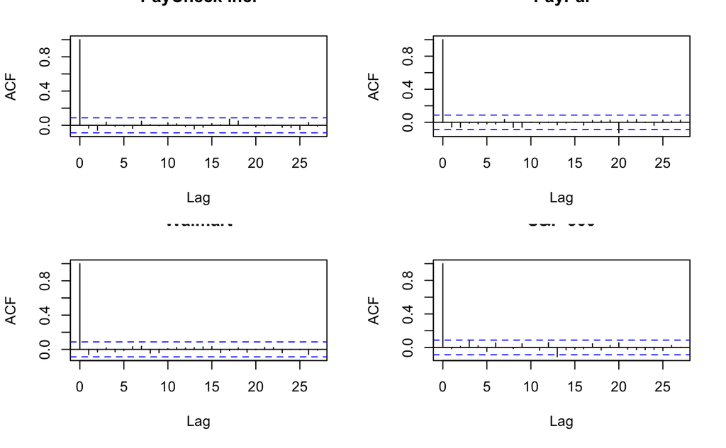

```r
acf(df_log_ret[,"SP"], main="S&P 500", na.action = na.pass)
```

The auto corrleation function applied to each security decays to zero, clearly indicating that the log-return series are stationary. However, PayPal security and S&P 500 present ocasions where the autocorrelation is outside the bounds which is an indication of non-stationary conditions.

In particular the autocorrelation that crossed the test bound for S&P 500 ocurred with a lag close to 15 and the autocorrelation that crossed the test bound for PayPal was at a lag of 20. This allow us to generalize by indicating that non of the securitiues autocorrelations at low lags (i.e., lower than 12) are outside the test bounds.

**Reminder:** * If the autocorrelation cross the test bound the hypothesis is rejected * If the autocorrelation does not cross the test bound the hypothesis is not rejected.

```r
pdf("Figure5-ACF-Lag-12.pdf",height=7,width=8)
par(mfrow=c(2,2))
acf(df_log_ret[,"PAYX"], lag.max = 12, main="PayCheck Inc.; Max Lag = 12", na.action = na.pass)
acf(df_log_ret[,"PYPL"], lag.max = 12, main="PayPal; Max Lag = 12", na.action = na.pass)
```

```r
acf(df_log_ret[,"WMT"], lag.max = 12, main="Walmart; Max Lag = 12", na.action = na.pass)
acf(df_log_ret[,"SP"], lag.max = 12, main="S&P 500; Max Lag = 12", na.action = na.pass)
```

```r
graphics.off()

par(mfrow=c(2,2))
acf(df_log_ret[,"PAYX"], lag.max = 12, main="PayCheck Inc.; Max Lag = 12", na.action = na.pass)
```

```r
acf(df_log_ret[,"PYPL"], lag.max = 12, main="PayPal; Max Lag = 12", na.action = na.pass)
acf(df_log_ret[,"WMT"], lag.max = 12, main="Walmart; Max Lag = 12", na.action = na.pass)
```

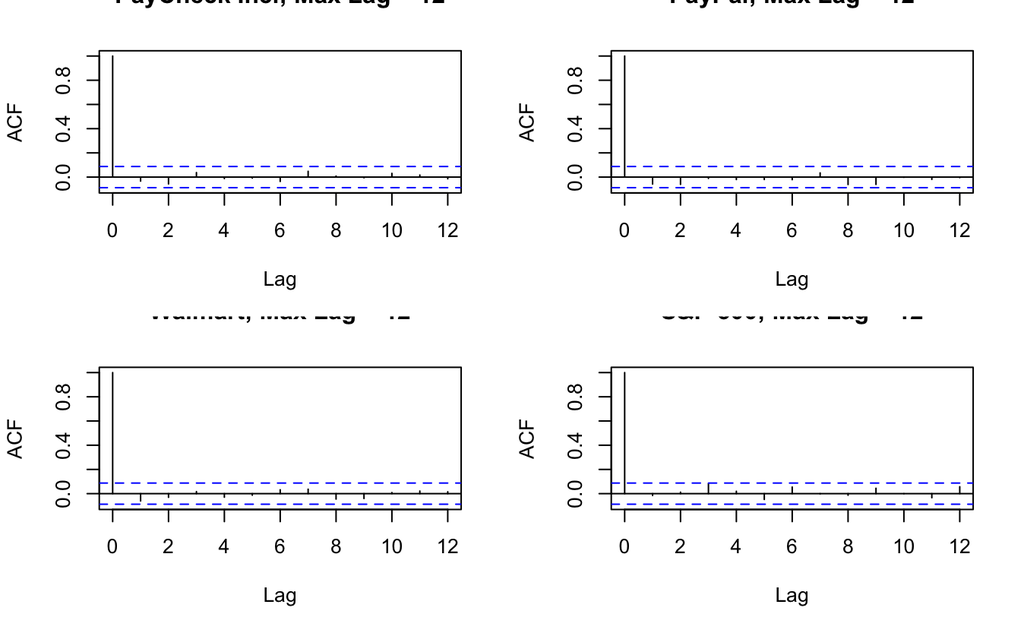

```r
acf(df_log_ret[,"SP"], lag.max = 12, main="S&P 500; Max Lag = 12", na.action = na.pass)
```

The ACF plot for the securities were obtained with a max lag value of 12 and we can observe that in this case; we have no autocorrelation crossing the test bound.

# Fitting the Models with AR(1)

**Note:** all the models are using the Maximum likelihood as the primary estimation method.

```r
fitPayxAr1 <- arima(df_log_ret[,"PAYX"], order = c(1,0,0))
fitPyplAr1 <- arima(df_log_ret[,"PYPL"], order = c(1,0,0))
fitWmtAr1 <- arima(df_log_ret[,"WMT"], order = c(1,0,0))
fitSpAr1 <- arima(df_log_ret[,"SP"], order = c(1,0,0))

Box.test(residuals(fitPayxAr1), lag = 5, type = "Ljung-Box", fitdf = 1)
```

```
    Box-Ljung test

data:  residuals(fitPayxAr1)
X-squared = 2.3528, df = 4, p-value = 0.6712
```

```r
Box.test(residuals(fitPyplAr1), lag = 5, type = "Ljung-Box", fitdf = 1)
```

```
    Box-Ljung test

data:  residuals(fitPyplAr1)
X-squared = 2.7622, df = 4, p-value = 0.5984
```

```r
Box.test(residuals(fitWmtAr1), lag = 5, type = "Ljung-Box", fitdf = 1)
```

```
    Box-Ljung test

data:  residuals(fitWmtAr1)
X-squared = 1.1887, df = 4, p-value = 0.8799
```

```r
Box.test(residuals(fitSpAr1), lag = 5, type = "Ljung-Box", fitdf = 1)
```

```
    Box-Ljung test

data:  residuals(fitSpAr1)
X-squared = 4.9379, df = 4, p-value = 0.2937
```

# Forecasting PayCheck AR Model

```r
pred.payx <- predict(fitPayxAr1, n.ahead = 100, se.fit = TRUE)

t1 = (503-99):503
t2 = 504:(504+49+50)
day_range = seq(-100,100,1)

xts1 <- as.data.frame(df_log_ret)

plot(day_range[1:100],xts1[t1,"PAYX"], type = "b",
     main = "Paycheck Inc Forecast", ylab = "log_return", xlab = "Days",
     xlim = c(-100,100))
points(day_range[101:200], pred.payx$pred,type="p",pch="*")
```

```r
lines(day_range[101:200], pred.payx$pred - 2*pred.payx$se)
lines(day_range[101:200], pred.payx$pred + 2*pred.payx$se)
```

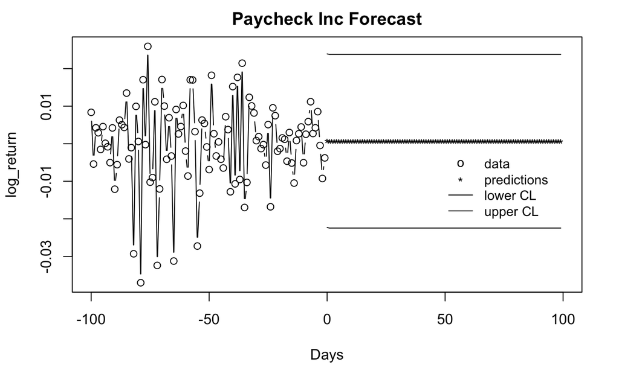

```r
legend(50,-0.001,c("data","predictions","lower CL","upper CL"),cex=0.9,
       box.lty=0,pch=c("o","*",NA,NA),lty=c(NA,NA,1,1))
```

# Forecasting Paypal AR(1) Model

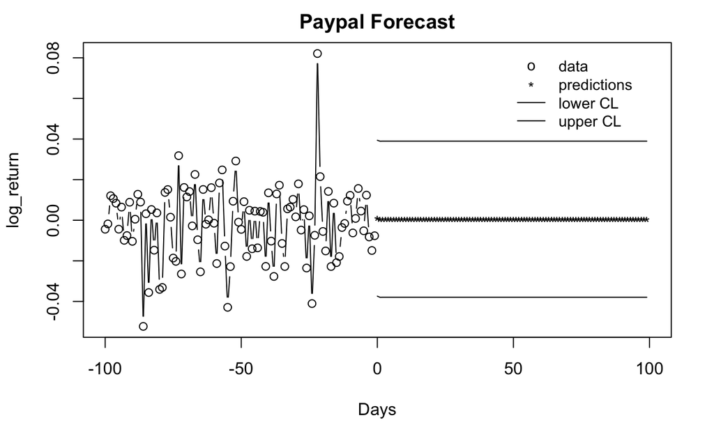

# Forecasting Walmart AR(1) Model

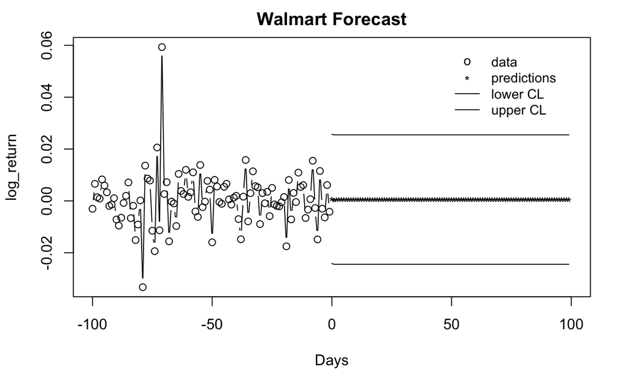

# Forecasting S&P 500 AR(1) Model

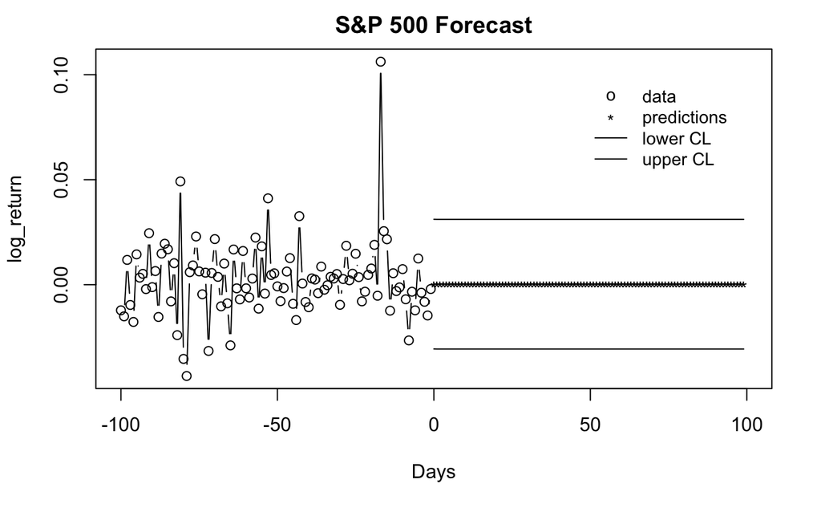

```r
pdf("Figure10-Forecast-All_AR1.pdf",height=7,width=8)
par(mfrow=c(2,2))
#
plot(day_range[1:100],xts1[t1,"PAYX"], type = "b",
     main = "Paycheck Inc Forecast", ylab = "log_return", xlab = "Days",
     xlim = c(-100,100))
points(day_range[101:200], pred.payx$pred,type="p",pch="*")
lines(day_range[101:200], pred.payx$pred - 2*pred.payx$se)
lines(day_range[101:200], pred.payx$pred + 2*pred.payx$se)
legend(25,0.001,c("data","predictions","lower CL","upper CL"),cex=0.9,
       box.lty=0,pch=c("o","*",NA,NA),lty=c(NA,NA,1,1))
#
plot(day_range[1:100],xts1[t1,"PYPL"], type = "b",
     main = "Paypal Forecast", ylab = "log_return", xlab = "Days",
     xlim = c(-100,100))
```

```r
points(day_range[101:200], pred.pypl$pred,type="p",pch="*")
lines(day_range[101:200], pred.pypl$pred - 2*pred.pypl$se)
lines(day_range[101:200], pred.pypl$pred + 2*pred.pypl$se)
legend(25,0.09,c("data","predictions","lower CL","upper CL"),cex=0.9,
       box.lty=0,pch=c("o","*",NA,NA),lty=c(NA,NA,1,1))
#
plot(day_range[1:100],xts1[t1,"WMT"], type = "b",
     main = "Walmart Forecast", ylab = "log_return", xlab = "Days",
     xlim = c(-100,100))
points(day_range[101:200], pred.wmt$pred,type="p",pch="*")
lines(day_range[101:200], pred.wmt$pred - 2*pred.wmt$se)
lines(day_range[101:200], pred.wmt$pred + 2*pred.wmt$se)
legend(25,0.06,c("data","predictions","lower CL","upper CL"),cex=0.9,
       box.lty=0,pch=c("o","*",NA,NA),lty=c(NA,NA,1,1))
#
plot(day_range[1:100],xts1[t1,"SP"], type = "b",
     main = "S&P 500 Forecast", ylab = "log_return", xlab = "Days",
     xlim = c(-100,100))
```

```r
points(day_range[101:200], pred.sp$pred,type="p",pch="*")
lines(day_range[101:200], pred.sp$pred - 2*pred.sp$se)
lines(day_range[101:200], pred.sp$pred + 2*pred.sp$se)
legend(25,0.1,c("data","predictions","lower CL","upper CL"),cex=0.9,
       box.lty=0,pch=c("o","*",NA,NA),lty=c(NA,NA,1,1))
#
graphics.off()
```

# Fitting the Models AR(p)

```r
Box.test(residuals(fitPayxArpBic), lag = 5, type = "Ljung-Box", fitdf = 1)
```

```
    Box-Ljung test

data:  residuals(fitPayxArpBic)
X-squared = 2.9946, df = 4, p-value = 0.5587
```

```r
Box.test(residuals(fitPayxArpAic), lag = 5, type = "Ljung-Box", fitdf = 1)
```

```
    Box-Ljung test

data:  residuals(fitPayxArpAic)
X-squared = 2.9946, df = 4, p-value = 0.5587
```

```r
Box.test(residuals(fitPyplArpBic), lag = 5, type = "Ljung-Box", fitdf = 1)
```

```
    Box-Ljung test

data:  residuals(fitPyplArpBic)
X-squared = 3.9883, df = 4, p-value = 0.4076
```

```r
Box.test(residuals(fitPyplArpAic), lag = 5, type = "Ljung-Box", fitdf = 1)
```

```
    Box-Ljung test

data:  residuals(fitPyplArpAic)
X-squared = 3.9883, df = 4, p-value = 0.4076
```

```r
Box.test(residuals(fitWmtArpBic), lag = 5, type = "Ljung-Box", fitdf = 1)
```

```
    Box-Ljung test

data:  residuals(fitWmtArpBic)
X-squared = 3.0017, df = 4, p-value = 0.5575
```

```r
Box.test(residuals(fitWmtArpAic), lag = 5, type = "Ljung-Box", fitdf = 1)
```

```
    Box-Ljung test

data:  residuals(fitWmtArpAic)
X-squared = 3.0017, df = 4, p-value = 0.5575
```

```r
Box.test(residuals(fitSpArpBic), lag = 5, type = "Ljung-Box", fitdf = 1)
```

```
    Box-Ljung test

data:  residuals(fitSpArpBic)
X-squared = 5.0444, df = 4, p-value = 0.2828
```

```r
Box.test(residuals(fitSpArpAic), lag = 5, type = "Ljung-Box", fitdf = 1)
```

```
    Box-Ljung test

data:  residuals(fitSpArpAic)
X-squared = 5.0444, df = 4, p-value = 0.2828
```

Below is the script to generate the forecast for all four securities only using AR(p) model and optimizing AIC.

```r
pred.payx.arp.aic <- predict(fitPayxArpAic, n.ahead = 100, se.fit = TRUE)
pred.pypl.arp.aic <- predict(fitPyplArpAic, n.ahead = 100, se.fit = TRUE)
pred.wmt.arp.aic <- predict(fitWmtArpAic, n.ahead = 100, se.fit = TRUE)
pred.sp.arp.aic <- predict(fitSpArpAic, n.ahead = 100, se.fit = TRUE)

pdf("Figure11-Forecast-All_ARp.pdf",height=7,width=8)
par(mfrow=c(2,2))
#
plot(day_range[1:100],xts1[t1,"PAYX"], type = "b",
     main = "Paycheck Inc Forecast", ylab = "log_return", xlab = "Days",
     xlim = c(-100,100))
points(day_range[101:200], pred.payx.arp.aic$pred,type="p",pch="*")
lines(day_range[101:200], pred.payx.arp.aic$pred - 2*pred.payx.arp.aic$se)
lines(day_range[101:200], pred.payx.arp.aic$pred + 2*pred.payx.arp.aic$se)
legend(25,0.001,c("data","predictions","lower CL","upper CL"),cex=0.9,
       box.lty=0,pch=c("o","*",NA,NA),lty=c(NA,NA,1,1))
#
plot(day_range[1:100],xts1[t1,"PYPL"], type = "b",
     main = "Paypal Forecast", ylab = "log_return", xlab = "Days",
     xlim = c(-100,100))
```

```r
points(day_range[101:200], pred.pypl.arp.aic$pred,type="p",pch="*")
lines(day_range[101:200], pred.pypl.arp.aic$pred - 2*pred.pypl.arp.aic$se)
lines(day_range[101:200], pred.pypl.arp.aic$pred + 2*pred.pypl.arp.aic$se)
legend(25,0.09,c("data","predictions","lower CL","upper CL"),cex=0.9,
       box.lty=0,pch=c("o","*",NA,NA),lty=c(NA,NA,1,1))
#
plot(day_range[1:100],xts1[t1,"WMT"], type = "b",
     main = "Walmart Forecast", ylab = "log_return", xlab = "Days",
     xlim = c(-100,100))
points(day_range[101:200], pred.wmt.arp.aic$pred,type="p",pch="*")
lines(day_range[101:200], pred.wmt.arp.aic$pred - 2*pred.wmt.arp.aic$se)
lines(day_range[101:200], pred.wmt.arp.aic$pred + 2*pred.wmt.arp.aic$se)
legend(25,0.06,c("data","predictions","lower CL","upper CL"),cex=0.9,
       box.lty=0,pch=c("o","*",NA,NA),lty=c(NA,NA,1,1))
#
plot(day_range[1:100],xts1[t1,"SP"], type = "b",
     main = "S&P 500 Forecast", ylab = "log_return", xlab = "Days",
     xlim = c(-100,100))
```

```r
points(day_range[101:200], pred.sp.arp.aic$pred,type="p",pch="*")
lines(day_range[101:200], pred.sp.arp.aic$pred - 2*pred.sp.arp.aic$se)
lines(day_range[101:200], pred.sp.arp.aic$pred + 2*pred.sp.arp.aic$se)
legend(25,0.1,c("data","predictions","lower CL","upper CL"),cex=0.9,
       box.lty=0,pch=c("o","*",NA,NA),lty=c(NA,NA,1,1))
#
graphics.off()
```

Below is the script to generate a figure that would allow us to compare the forecast created using the predictions for the AR(1) model and AR(p) model for the PayCheck Inc. and Paypal securities.

```r
pdf("Figure12-Forecast-Payx-Pypl_AR1_ARp.pdf",height=7,width=8)
par(mfrow=c(2,2))
#
plot(day_range[1:100],xts1[t1,"PAYX"], type = "b",
     main = "Paycheck Inc Forecast - AR(p)", ylab = "log_return", xlab = "Days",
     xlim = c(-100,100))
points(day_range[101:200], pred.payx.arp.aic$pred,type="p",pch="*")
lines(day_range[101:200], pred.payx.arp.aic$pred - 2*pred.payx.arp.aic$se)
lines(day_range[101:200], pred.payx.arp.aic$pred + 2*pred.payx.arp.aic$se)
legend(25,0.001,c("data","predictions","lower CL","upper CL"),cex=0.9,
       box.lty=0,pch=c("o","*",NA,NA),lty=c(NA,NA,1,1))

plot(day_range[1:100],xts1[t1,"PAYX"], type = "b",
     main = "Paycheck Inc Forecast - AR(1)", ylab = "log_return", xlab = "Days",
     xlim = c(-100,100))
```

```r
points(day_range[101:200], pred.payx$pred,type="p",pch="*")
lines(day_range[101:200], pred.payx$pred - 2*pred.payx$se)
lines(day_range[101:200], pred.payx$pred + 2*pred.payx$se)
legend(25,0.001,c("data","predictions","lower CL","upper CL"),cex=0.9,
       box.lty=0,pch=c("o","*",NA,NA),lty=c(NA,NA,1,1))

plot(day_range[1:100],xts1[t1,"PYPL"], type = "b",
     main = "Paypal Forecast - AR(p)", ylab = "log_return", xlab = "Days",
     xlim = c(-100,100))
points(day_range[101:200], pred.pypl.arp.aic$pred,type="p",pch="*")
lines(day_range[101:200], pred.pypl.arp.aic$pred - 2*pred.pypl.arp.aic$se)
lines(day_range[101:200], pred.pypl.arp.aic$pred + 2*pred.pypl.arp.aic$se)
legend(25,0.09,c("data","predictions","lower CL","upper CL"),cex=0.9,
       box.lty=0,pch=c("o","*",NA,NA),lty=c(NA,NA,1,1))

plot(day_range[1:100],xts1[t1,"PYPL"], type = "b",
     main = "Paypal Forecast - AR(1)", ylab = "log_return", xlab = "Days",
     xlim = c(-100,100))
```

```r
points(day_range[101:200], pred.pypl$pred,type="p",pch="*")
lines(day_range[101:200], pred.pypl$pred - 2*pred.pypl$se)
lines(day_range[101:200], pred.pypl$pred + 2*pred.pypl$se)
legend(25,0.09,c("data","predictions","lower CL","upper CL"),cex=0.9,
       box.lty=0,pch=c("o","*",NA,NA),lty=c(NA,NA,1,1))
#
graphics.off()
```

Below is the script to generate a figure that would allow us to compare the forecast created using the predictions for the AR(1) model and AR(p) model for the Walmart and S&P 500 securities.

```r
pdf("Figure13-Forecast-Wmt-Sp_AR1_ARp.pdf",height=7,width=8)
par(mfrow=c(2,2))
#
plot(day_range[1:100],xts1[t1,"WMT"], type = "b",
     main = "Walmart Forecast - AR(p)", ylab = "log_return", xlab = "Days",
     xlim = c(-100,100))
points(day_range[101:200], pred.wmt.arp.aic$pred,type="p",pch="*")
lines(day_range[101:200], pred.wmt.arp.aic$pred - 2*pred.wmt.arp.aic$se)
lines(day_range[101:200], pred.wmt.arp.aic$pred + 2*pred.wmt.arp.aic$se)
legend(25,0.06,c("data","predictions","lower CL","upper CL"),cex=0.9,
       box.lty=0,pch=c("o","*",NA,NA),lty=c(NA,NA,1,1))

plot(day_range[1:100],xts1[t1,"WMT"], type = "b",
     main = "Walmart Forecast - AR(1)", ylab = "log_return", xlab = "Days",
     xlim = c(-100,100))
```

```r
points(day_range[101:200], pred.wmt$pred,type="p",pch="*")
lines(day_range[101:200], pred.wmt$pred - 2*pred.wmt$se)
lines(day_range[101:200], pred.wmt$pred + 2*pred.wmt$se)
legend(25,0.06,c("data","predictions","lower CL","upper CL"),cex=0.9,
       box.lty=0,pch=c("o","*",NA,NA),lty=c(NA,NA,1,1))

plot(day_range[1:100],xts1[t1,"SP"], type = "b",
     main = "S&P 500 Forecast - AR(p)", ylab = "log_return", xlab = "Days",
     xlim = c(-100,100))
points(day_range[101:200], pred.sp.arp.aic$pred,type="p",pch="*")
lines(day_range[101:200], pred.sp.arp.aic$pred - 2*pred.sp.arp.aic$se)
lines(day_range[101:200], pred.sp.arp.aic$pred + 2*pred.sp.arp.aic$se)
legend(25,0.1,c("data","predictions","lower CL","upper CL"),cex=0.9,
       box.lty=0,pch=c("o","*",NA,NA),lty=c(NA,NA,1,1))

plot(day_range[1:100],xts1[t1,"SP"], type = "b",
     main = "S&P 500 Forecast - AR(1)", ylab = "log_return", xlab = "Days",
     xlim = c(-100,100))
```

```r
points(day_range[101:200], pred.sp$pred,type="p",pch="*")
lines(day_range[101:200], pred.sp$pred - 2*pred.sp$se)
lines(day_range[101:200], pred.sp$pred + 2*pred.sp$se)
legend(25,0.1,c("data","predictions","lower CL","upper CL"),cex=0.9,
       box.lty=0,pch=c("o","*",NA,NA),lty=c(NA,NA,1,1))
#
graphics.off()
```

# Fitting MA models using MA(3) and MA(q)

```r
Box.test(residuals(fitPayxMa3), lag = 5, type = "Ljung-Box", fitdf = 1)
```

```
    Box-Ljung test

data:  residuals(fitPayxMa3)
X-squared = 0.16075, df = 4, p-value = 0.9969
```

```r
Box.test(residuals(fitPayxMaqAic), lag = 5, type = "Ljung-Box", fitdf = 1)
```

```
    Box-Ljung test

data:  residuals(fitPayxMaqAic)
X-squared = 2.9946, df = 4, p-value = 0.5587
```

```r
Box.test(residuals(fitPyplMa3), lag = 5, type = "Ljung-Box", fitdf = 1)
```

```
    Box-Ljung test

data:  residuals(fitPyplMa3)
X-squared = 0.52281, df = 4, p-value = 0.9712
```

```r
Box.test(residuals(fitPyplMaqAic), lag = 5, type = "Ljung-Box", fitdf = 1)
```

```
    Box-Ljung test

data:  residuals(fitPyplMaqAic)
X-squared = 3.9883, df = 4, p-value = 0.4076
```

```r
Box.test(residuals(fitWmtMa3), lag = 5, type = "Ljung-Box", fitdf = 1)
```

```
    Box-Ljung test

data:  residuals(fitWmtMa3)
X-squared = 0.5088, df = 4, p-value = 0.9726
```

```r
Box.test(residuals(fitWmtMaqAic), lag = 5, type = "Ljung-Box", fitdf = 1)
```

```
    Box-Ljung test

data:  residuals(fitWmtMaqAic)
X-squared = 3.0017, df = 4, p-value = 0.5575
```

```r
Box.test(residuals(fitSpMa3), lag = 5, type = "Ljung-Box", fitdf = 1)
```

```
    Box-Ljung test

data:  residuals(fitSpMa3)
X-squared = 1.2553, df = 4, p-value = 0.8689
```

```r
Box.test(residuals(fitSpMaqAic), lag = 5, type = "Ljung-Box", fitdf = 1)
```

```
    Box-Ljung test

data:  residuals(fitSpMaqAic)
X-squared = 5.0444, df = 4, p-value = 0.2828
```

```r
pred.payx.ma3 <- predict(fitPayxMa3, n.ahead = 100, se.fit = TRUE)
pred.pypl.ma3 <- predict(fitPyplMa3, n.ahead = 100, se.fit = TRUE)
pred.wmt.ma3 <- predict(fitWmtMa3, n.ahead = 100, se.fit = TRUE)
pred.sp.ma3 <- predict(fitSpMa3, n.ahead = 100, se.fit = TRUE)

pred.payx.maq.aic <- predict(fitPayxMaqAic, n.ahead = 100, se.fit = TRUE)
pred.pypl.maq.aic <- predict(fitPyplMaqAic, n.ahead = 100, se.fit = TRUE)
pred.wmt.maq.aic <- predict(fitWmtMaqAic, n.ahead = 100, se.fit = TRUE)
pred.sp.maq.aic <- predict(fitSpMaqAic, n.ahead = 100, se.fit = TRUE)
```

```r
pdf("Figure14-Forecast-Payx-Pypl_MA3_MAq.pdf",height=7,width=8)
par(mfrow=c(2,2))
#
plot(day_range[1:100],xts1[t1,"PAYX"], type = "b",
     main = "Paycheck Inc Forecast - MA(3)", ylab = "log_return", xlab = "Days",
     xlim = c(-100,100))
points(day_range[101:200], pred.payx.ma3$pred,type="p",pch="*")
lines(day_range[101:200], pred.payx.ma3$pred - 2*pred.payx.ma3$se)
lines(day_range[101:200], pred.payx.ma3$pred + 2*pred.payx.ma3$se)
legend(25,0.001,c("data","predictions","lower CL","upper CL"),cex=0.9,
       box.lty=0,pch=c("o","*",NA,NA),lty=c(NA,NA,1,1))

plot(day_range[1:100],xts1[t1,"PAYX"], type = "b",
     main = "Paycheck Inc Forecast - MA(q)", ylab = "log_return", xlab = "Days",
     xlim = c(-100,100))
```

```r
points(day_range[101:200], pred.payx.maq.aic$pred,type="p",pch="*")
lines(day_range[101:200], pred.payx.maq.aic$pred - 2*pred.payx.maq.aic$se)
lines(day_range[101:200], pred.payx.maq.aic$pred + 2*pred.payx.maq.aic$se)
legend(25,0.001,c("data","predictions","lower CL","upper CL"),cex=0.9,
       box.lty=0,pch=c("o","*",NA,NA),lty=c(NA,NA,1,1))

plot(day_range[1:100],xts1[t1,"PYPL"], type = "b",
     main = "Paypal Forecast - AR(p)", ylab = "log_return", xlab = "Days",
     xlim = c(-100,100))
points(day_range[101:200], pred.pypl.ma3$pred,type="p",pch="*")
lines(day_range[101:200], pred.pypl.ma3$pred - 2*pred.pypl.ma3$se)
lines(day_range[101:200], pred.pypl.ma3$pred + 2*pred.pypl.ma3$se)
legend(25,0.09,c("data","predictions","lower CL","upper CL"),cex=0.9,
       box.lty=0,pch=c("o","*",NA,NA),lty=c(NA,NA,1,1))

plot(day_range[1:100],xts1[t1,"PYPL"], type = "b",
     main = "Paypal Forecast - AR(1)", ylab = "log_return", xlab = "Days",
     xlim = c(-100,100))
```

```r
points(day_range[101:200], pred.pypl.maq.aic$pred,type="p",pch="*")
lines(day_range[101:200], pred.pypl.maq.aic$pred - 2*pred.pypl.maq.aic$se)
lines(day_range[101:200], pred.pypl.maq.aic$pred + 2*pred.pypl.maq.aic$se)
legend(25,0.09,c("data","predictions","lower CL","upper CL"),cex=0.9,
       box.lty=0,pch=c("o","*",NA,NA),lty=c(NA,NA,1,1))
#
graphics.off()
```

```r
pdf("Figure15-Forecast-Wmt-Sp_MA3_MAq.pdf",height=7,width=8)
par(mfrow=c(2,2))
#
plot(day_range[1:100],xts1[t1,"WMT"], type = "b",
     main = "Walmart Forecast - MA(3)", ylab = "log_return", xlab = "Days",
     xlim = c(-100,100))
points(day_range[101:200], pred.wmt.ma3$pred,type="p",pch="*")
lines(day_range[101:200], pred.wmt.ma3$pred - 2*pred.wmt.ma3$se)
lines(day_range[101:200], pred.wmt.ma3$pred + 2*pred.wmt.ma3$se)
legend(25,0.06,c("data","predictions","lower CL","upper CL"),cex=0.9,
       box.lty=0,pch=c("o","*",NA,NA),lty=c(NA,NA,1,1))

plot(day_range[1:100],xts1[t1,"WMT"], type = "b",
     main = "Walmart Forecast - MA(q)", ylab = "log_return", xlab = "Days",
     xlim = c(-100,100))
```

```r
points(day_range[101:200], pred.wmt.maq.aic$pred,type="p",pch="*")
lines(day_range[101:200], pred.wmt.maq.aic$pred - 2*pred.wmt.maq.aic$se)
lines(day_range[101:200], pred.wmt.maq.aic$pred + 2*pred.wmt.maq.aic$se)
legend(25,0.06,c("data","predictions","lower CL","upper CL"),cex=0.9,
       box.lty=0,pch=c("o","*",NA,NA),lty=c(NA,NA,1,1))

plot(day_range[1:100],xts1[t1,"SP"], type = "b",
     main = "S&P 500 Forecast - MA(3)", ylab = "log_return", xlab = "Days",
     xlim = c(-100,100))
points(day_range[101:200], pred.sp.ma3$pred,type="p",pch="*")
lines(day_range[101:200], pred.sp.ma3$pred - 2*pred.sp.ma3$se)
lines(day_range[101:200], pred.sp.ma3$pred + 2*pred.sp.ma3$se)
legend(25,0.1,c("data","predictions","lower CL","upper CL"),cex=0.9,
       box.lty=0,pch=c("o","*",NA,NA),lty=c(NA,NA,1,1))

plot(day_range[1:100],xts1[t1,"SP"], type = "b",
     main = "S&P 500 Forecast - MA(q)", ylab = "log_return", xlab = "Days",
     xlim = c(-100,100))
```

```r
points(day_range[101:200], pred.sp.maq.aic$pred,type="p",pch="*")
lines(day_range[101:200], pred.sp.maq.aic$pred - 2*pred.sp.maq.aic$se)
lines(day_range[101:200], pred.sp.maq.aic$pred + 2*pred.sp.maq.aic$se)
legend(25,0.1,c("data","predictions","lower CL","upper CL"),cex=0.9,
       box.lty=0,pch=c("o","*",NA,NA),lty=c(NA,NA,1,1))
#
graphics.off()
```

# Fitting ARMA models using ARMA(3,3) and ARMA(p,q)

```r
fitPayxArMa33 <- arima(df_log_ret[,"PAYX"], order = c(3,0,3))
fitPyplArMa33 <- arima(df_log_ret[,"PYPL"], order = c(3,0,3))
fitWmtArMa33 <- arima(df_log_ret[,"WMT"], order = c(3,0,3))
fitSpArMa33 <- arima(df_log_ret[,"SP"], order = c(3,0,3))

fitPayxArmapqAic <- auto.arima(df_log_ret[,"PAYX"], max.p = 20, max.q = 20, ic = "bic")
fitPyplArmapqAic <- auto.arima(df_log_ret[,"PYPL"], max.p = 20, max.q = 20, ic = "bic")
fitWmtArmapqAic <- auto.arima(df_log_ret[,"WMT"], max.p = 20, max.q = 20, ic = "bic")
fitSpArmapqAic <- auto.arima(df_log_ret[,"SP"], max.p = 20, max.q = 20, ic = "bic")

Box.test(residuals(fitPayxArma3), lag = 5, type = "Ljung-Box", fitdf = 1)
Box.test(residuals(fitPayxMaqAic), lag = 5, type = "Ljung-Box", fitdf = 1)

Box.test(residuals(fitPyplMa3), lag = 5, type = "Ljung-Box", fitdf = 1)
Box.test(residuals(fitPyplMaqAic), lag = 5, type = "Ljung-Box", fitdf = 1)

Box.test(residuals(fitWmtMa3), lag = 5, type = "Ljung-Box", fitdf = 1)
Box.test(residuals(fitWmtMaqAic), lag = 5, type = "Ljung-Box", fitdf = 1)

Box.test(residuals(fitSpMa3), lag = 5, type = "Ljung-Box", fitdf = 1)
Box.test(residuals(fitSpMaqAic), lag = 5, type = "Ljung-Box", fitdf = 1)
```

[output not shown]